# Diet data exploration

I processed (which is to say my amazing helper Chris processed) the nest cam images from one site, and before we move on I want to make sure this protocol produces usable data so this is just me playing around a bit.

```r
# Load some libraries.
library('tidyverse')
```

```r
# Load in the filled csv.
photos_4 <-
  read.csv('C:/Users/Gwyn/sfuvault/move-space/data/interim/TMC_photos_4.csv')

# Load in the empty csv.
photos_4.old <-
  read_csv('C:/Users/Gwyn/sfuvault/move-space/data/interim/n_cam_csv/TMC_photos_4.csv')

# Patch the new with the old.
photos_4$datetime <- photos_4.old$datetime

# Save the fixed new one.
write.csv(photos_4,
    file='C:/Users/Gwyn/sfuvault/move-space/data/interim/TMC_photos_4_patch.csv',
        row.names=FALSE)

# The fourth csv is already loaded, so drop it from the list.
csv.list <- csv.list[-11]

# And start over...
```

Nope, still didn’t work. Either there are more datetime problems or… there are more datetime problems. I guess I’ll have to load them all in individually and check them.

[output not shown]

```r
head(photos.01)

head(photos.02)
```

[output not shown]

|  | filename | datetime | serial | site | interest | live.chicks | class | family | genus | species | common | size | comments |
| --- | --- | --- | --- | --- | --- | --- | --- | --- | --- | --- | --- | --- | --- |
| 1 | RCNX0229.JPG | 2019-06-18 4:00:00 | UXP9BM02019728 | TMC |  | NA |  |  |  |  |  |  |  |
| 2 | RCNX0230.JPG | 2019-06-18 4:21:59 | UXP9BM02019728 | TMC |  | NA |  |  |  |  |  |  |  |
| 3 | RCNX0231.JPG | 2019-06-18 4:22:00 | UXP9BM02019728 | TMC |  | NA |  |  |  |  |  |  |  |
| 4 | RCNX0232.JPG | 2019-06-18 4:22:01 | UXP9BM02019728 | TMC |  | NA |  |  |  |  |  |  |  |
| 5 | RCNX0233.JPG | 2019-06-18 4:24:04 | UXP9BM02019728 | TMC |  | NA |  |  |  |  |  |  |  |
| 6 | RCNX0234.JPG | 2019-06-18 4:24:05 | UXP9BM02019728 | TMC |  | NA |  |  |  |  |  |  |  |

```r
head(photos.03)
```

|  | filename | datetime | serial | site | interest | live.chicks | class | family | genus | species | common | size | comments |
| --- | --- | --- | --- | --- | --- | --- | --- | --- | --- | --- | --- | --- | --- |
| 1 | RCNX2475.JPG | 6/25/2019 4:00 | UXP9BM02019728 | TMC |  | NA |  |  |  |  |  |  |  |
| 2 | RCNX2476.JPG | 6/25/2019 4:30 | UXP9BM02019728 | TMC |  | NA |  |  |  |  |  |  |  |
| 3 | RCNX2477.JPG | 6/25/2019 5:00 | UXP9BM02019728 | TMC |  | NA |  |  |  |  |  |  |  |
| 4 | RCNX2478.JPG | 6/25/2019 5:30 | UXP9BM02019728 | TMC |  | NA |  |  |  |  |  |  |  |
| 5 | RCNX2479.JPG | 6/25/2019 5:33 | UXP9BM02019728 | TMC |  | NA |  |  |  |  |  |  |  |
| 6 | RCNX2480.JPG | 6/25/2019 5:33 | UXP9BM02019728 | TMC |  | NA |  |  |  |  |  |  |  |

```r
head(photos.04)
```

|  | filename | datetime | serial | site | interest | live.chicks | class | family | genus | species | common | size | comments |
| --- | --- | --- | --- | --- | --- | --- | --- | --- | --- | --- | --- | --- | --- |
| 1 | RCNX3299.JPG | 7/2/2019 4:00 | UXP9BM02019728 | TMC |  | NA |  |  |  |  | NA | NA |  |
| 2 | RCNX3300.JPG | 7/2/2019 4:30 | UXP9BM02019728 | TMC |  | NA |  |  |  |  | NA | NA |  |
| 3 | RCNX3301.JPG | 7/2/2019 5:00 | UXP9BM02019728 | TMC |  | NA |  |  |  |  | NA | NA |  |
| 4 | RCNX3302.JPG | 7/2/2019 5:30 | UXP9BM02019728 | TMC |  | NA |  |  |  |  | NA | NA |  |
| 5 | RCNX3303.JPG | 7/2/2019 6:00 | UXP9BM02019728 | TMC |  | NA |  |  |  |  | NA | NA |  |
| 6 | RCNX3304.JPG | 7/2/2019 6:30 | UXP9BM02019728 | TMC |  | NA |  |  |  |  | NA | NA |  |

```r
head(photos.05)
```

|  | filename | datetime | serial | site | interest | live.chicks | class | family | genus | species | common | size | comments |
| --- | --- | --- | --- | --- | --- | --- | --- | --- | --- | --- | --- | --- | --- |
| 1 | RCNX3580.JPG | 7/9/2019 4:00 | UXP9BM02019728 | TMC |  | NA | NA | NA | NA | NA | NA | NA | NA |
| 2 | RCNX3581.JPG | 7/9/2019 4:30 | UXP9BM02019728 | TMC |  | NA | NA | NA | NA | NA | NA | NA | NA |
| 3 | RCNX3582.JPG | 7/9/2019 5:00 | UXP9BM02019728 | TMC |  | NA | NA | NA | NA | NA | NA | NA | NA |
| 4 | RCNX3583.JPG | 7/9/2019 5:30 | UXP9BM02019728 | TMC |  | NA | NA | NA | NA | NA | NA | NA | NA |
| 5 | RCNX3584.JPG | 7/9/2019 6:00 | UXP9BM02019728 | TMC |  | NA | NA | NA | NA | NA | NA | NA | NA |
| 6 | RCNX3585.JPG | 7/9/2019 6:04 | UXP9BM02019728 | TMC | visit | NA | NA | NA | NA | NA | NA | NA | NA |

So it looks like both 3, 4, and 5 are missing their seconds. I’ll do the patch thing for both. Also, 3, 4, and 5 have a / instead of - for their dates, which I’ll have to fix.

```r
# Save it!
write.csv(df,
    file='C:/Users/Gwyn/sfuvault/move-space/data/processed/TMC_photos_short.csv', row.names=FALSE))
```

```
Error: unexpected ')' in:
"write.csv(df,
    file='C:/Users/Gwyn/sfuvault/move-space/data/processed/TMC_photos_short.csv', row.names=FALSE))"
```

I’ll stick to the first few weeks of data, since past that point the nest was abandoned and there’s nothing to look at. To start with, I’ll look at the frequency of prey deliveries.

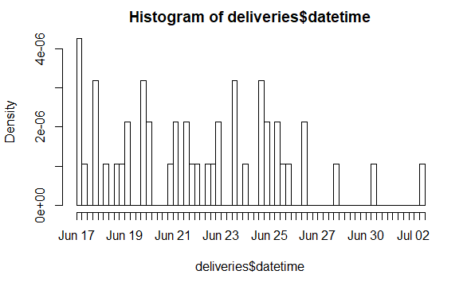